# 2˚ Shifts global area change analysis

| latitude_start | latitude_end | area_rasterarea | area_equalareaproj | area_rgeos_gArea | percent_change | area_1000s | hemisphere | change_above_2fold | latitude_mid |
| --- | --- | --- | --- | --- | --- | --- | --- | --- | --- |
| 0 | 2 | 23726.0285 | 23724.429 | 23724.429 | NA | 23.7260285 | north | NA | 1 |
| 2 | 4 | 43708.6062 | 43711.316 | 43711.316 | 0.84222177 | 43.7086062 | north | 0 | 3 |
| 4 | 6 | 74286.0105 | 74292.388 | 74292.388 | 0.69957400 | 74.2860105 | north | 0 | 5 |
| 6 | 8 | 60135.0866 | 60145.565 | 60145.565 | -0.19049245 | 60.1350866 | north | 0 | 7 |
| 8 | 10 | 52081.9569 | 52102.668 | 52102.668 | -0.13391732 | 52.0819569 | north | 0 | 9 |
| 10 | 12 | 46812.1315 | 46825.605 | 46825.605 | -0.10118332 | 46.8121315 | north | 0 | 11 |
| 12 | 14 | 60633.4906 | 60668.956 | 60668.956 | 0.29525165 | 60.6334906 | north | 0 | 13 |
| 14 | 16 | 100701.5011 | 100760.483 | 100760.483 | 0.66082309 | 100.7015011 | north | 0 | 15 |
| 16 | 18 | 30253.3284 | 30268.081 | 30268.081 | -0.69957421 | 30.2533284 | north | -1 | 17 |
| 18 | 20 | 31778.1577 | 31813.563 | 31813.563 | 0.05040203 | 31.7781577 | north | 0 | 19 |

[output cut: 28 more lines]

For ease, merge areas (I need to do this when I actually have matched them in degree_shifts_projected_2degrees script)

```r
west_pac_shelf_areas.r <- west_pac_shelf_areas[,1:3][,region := "west_pac"]
west_atl_shelf_areas.r <- west_atl_shelf_areas[,1:3][,region := "west_atl"]
west_ind_shelf_areas.r <- west_ind_shelf_areas[,1:3][,region := "west_ind"]
east_pac_shelf_areas.r <- east_pac_shelf_areas[,1:3][,region := "east_pac"]
east_atl_shelf_areas.r <- east_atl_shelf_areas[,1:3][,region := "east_atl"]
east_ind_shelf_areas.r <- east_ind_shelf_areas[,1:3][,region := "east_ind"]



shelf_areas <- rbind(west_pac_shelf_areas.r, west_atl_shelf_areas.r, west_ind_shelf_areas.r, east_pac_shelf_areas.r, east_atl_shelf_areas.r, east_ind_shelf_areas.r)

shelf_areas[,hemisphere := ifelse(latitude_end >0, "Northern", "Southern")]

#be sure to order table first so that shift is calculated accurately

#include absolute value of latitude end to help with sorting
shelf_areas[,latitude_end_abs  := abs(latitude_end)]
setkey(shelf_areas, region, hemisphere, latitude_end_abs) #sort by region, and then hemisphere, and then latitude_end_abs increasing (because we want to be moving outward from the equator)

#include mid_latitude value for plotting
shelf_areas[,latitude_mid  := (latitude_start+latitude_end)/2]
```

Calculate change in area from one bin to the next

```
Warning: Removed 12 rows containing missing values (position_stack).
```

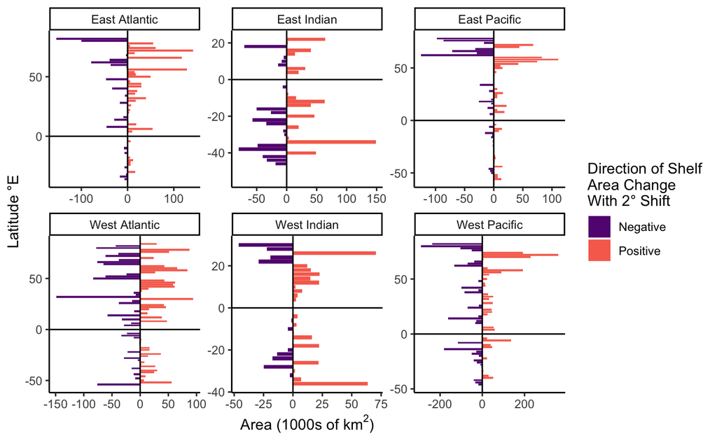

```r
#area change
shelf_areas[, area_change :=  area_rasterarea -  data.table::shift(area_rasterarea, n = 1, type = "lag"), .(region, hemisphere)] #change in species from previous bin to this bin?
#note that it's important to include grouping for region so that calculations are correct, and there's always a gain at the lowest latitude

#positive versus negative change

shelf_areas[,change_dir := ifelse(area_change > 0, "positive", "negative")]

#add labels to regions
shelf_areas[,region := factor(region, levels = c("east_atl", "east_ind", "east_pac", "west_atl", "west_ind", "west_pac"), labels = c("East Atlantic","East Indian","East Pacific","West Atlantic","West Indian","West Pacific"))]

(area_change_latitude  <- ggplot(data = shelf_areas) +
  geom_col(aes(x=latitude_end, y=area_change/1000, fill = change_dir)) +
 labs(x=paste0("Latitude ","\u00B0","E"), y = expression(paste("Area (1000s of ", km^{2},")"))) +
     scale_fill_viridis_d(option = "A", begin = 0.3, end = 0.7, name = "Direction of Shelf\nArea Change\nWith 2\u00B0 Shift", labels = c("Negative", "Positive")) +
  geom_vline(xintercept = 0) +
  geom_hline(yintercept = 0) +
  coord_flip() +
  theme_classic() +
   facet_wrap(~region, scales = "free"))
ggsave(area_change_latitude, file = "area_change_latitude.jpg")
```

Let’s make this same figure but for species lost or gained.

Make datatable with statistics

```r
shelf_areas[, sum_change := sum(area_change, na.rm = T)] #total change in area across all shelf regions
shelf_areas[, sum_change_reg := sum(area_change, na.rm = T), region] #total change in area by region
shelf_areas[, sum_change_hemis := sum(area_change, na.rm = T), hemisphere] #total change in area by hemisphere
shelf_areas[, sum_change_hemis_reg := sum(area_change, na.rm = T), .(region, hemisphere)] #total change in area by both hemisphere and region

shelf_areas[, original_area_reg := sum(area_rasterarea, na.rm = T), region] #original area by region
shelf_areas[, final_area_reg := original_area_reg + sum_change_reg, region] #final area by region

(shelf_area_change_all_stats <- unique(shelf_areas[,.(region, hemisphere, sum_change, sum_change_reg, sum_change_hemis, sum_change_hemis_reg)]))
```

| region | hemisphere | sum_change | sum_change_reg | sum_change_hemis | sum_change_hemis_reg |
| --- | --- | --- | --- | --- | --- |
| East Atlantic | Northern | 376959.5 | 269028.89 | 496580.8 | 265553.068 |
| East Atlantic | Southern | 376959.5 | 269028.89 | -119621.2 | 3475.819 |
| East Indian | Northern | 376959.5 | 56526.36 | 496580.8 | 72486.525 |
| East Indian | Southern | 376959.5 | 56526.36 | -119621.2 | -15960.160 |
| East Pacific | Northern | 376959.5 | 20381.28 | 496580.8 | -3684.254 |
| East Pacific | Southern | 376959.5 | 20381.28 | -119621.2 | 24065.539 |
| West Atlantic | Northern | 376959.5 | 22998.00 | 496580.8 | 12969.764 |
| West Atlantic | Southern | 376959.5 | 22998.00 | -119621.2 | 10028.232 |
| West Indian | Northern | 376959.5 | 128879.08 | 496580.8 | 57478.367 |
| West Indian | Southern | 376959.5 | 128879.08 | -119621.2 | 71400.717 |

[output cut: 2 more lines]

```r
(shelf_area_change_region_stats <- unique(shelf_areas[,.(region, sum_change_reg)]))
```

| region | sum_change_reg |
| --- | --- |
| East Atlantic | 269028.89 |
| East Indian | 56526.36 |
| East Pacific | 20381.28 |
| West Atlantic | 22998.00 |
| West Indian | 128879.08 |
| West Pacific | -120854.09 |

```r
(shelf_area_change_hemis_stats <- unique(shelf_areas[,.(hemisphere, sum_change_hemis)]))
```

| hemisphere | sum_change_hemis |
| --- | --- |
| Northern | 496580.8 |
| Southern | -119621.2 |

```r
(shelf_area_change_hemis_reg_stats <- unique(shelf_areas[,.(hemisphere, region, sum_change_hemis_reg)]))
```

| hemisphere | region | sum_change_hemis_reg |
| --- | --- | --- |
| Northern | East Atlantic | 265553.068 |
| Southern | East Atlantic | 3475.819 |
| Northern | East Indian | 72486.525 |
| Southern | East Indian | -15960.160 |
| Northern | East Pacific | -3684.254 |
| Southern | East Pacific | 24065.539 |
| Northern | West Atlantic | 12969.764 |
| Southern | West Atlantic | 10028.232 |
| Northern | West Indian | 57478.367 |
| Southern | West Indian | 71400.717 |

[output cut: 2 more lines]

```r
#color by direction
shelf_area_change_hemis_reg_stats[,change_direction := factor(ifelse(sum_change_hemis_reg >1, "Gain", "Loss"))]

#individual bins
shelf_areas[, original_spp_predicted_meixler :=
              exp(6.854 + (0.185 * log(area_rasterarea)) -  (1.084 * log(abs(0.5*(latitude_start+latitude_end)))))]

shelf_areas[, original_spp_predicted_levin := 16.18*area_rasterarea^0.226]

#be sure to order table so that shift is used accurately (I did this above also, this is just a check)
#include absolute value of latitude end
setkey(shelf_areas, region, hemisphere, latitude_end_abs)

#species change
shelf_areas[, change_spp_predicted_meixler :=  original_spp_predicted_meixler -  data.table::shift(original_spp_predicted_meixler, n = 1, type = "lag"), .(region, hemisphere)] #change in species from previous bin to this bin?
#note that it's important to include grouping for region so that calculations are correct, and there's always a gain at the lowest latitude

shelf_areas[, change_spp_predicted_levin :=  original_spp_predicted_levin -  data.table::shift(original_spp_predicted_levin, n = 1, type = "lag"), .(region, hemisphere)] #change in species from previous bin to this bin?

#percent change
shelf_areas[, percent_change_richness := (original_spp_predicted_levin-data.table::shift(original_spp_predicted_levin, type = "lag"))/data.table::shift(original_spp_predicted_levin, type = "lag"), .(region,hemisphere)]
shelf_areas[,spp_per_change_significant := ifelse(percent_change_richness >= 1, "Gain",ifelse(percent_change_richness <= -0.5, "Loss","NA"))]

#new data table with only these values
shelf_areas_highlight <- shelf_areas[spp_per_change_significant == "Gain" | spp_per_change_significant == "Loss"]

#color code by direction of spp gain or loss
shelf_areas[, spp_change_pos_neg_meixler := ifelse(change_spp_predicted_meixler > 0, "Positive","Negative")]
shelf_areas[, spp_change_pos_neg_levin := ifelse(change_spp_predicted_levin > 0, "Positive","Negative")]

#full stats for spp change
shelf_areas[,spp_change_levin_by_reg := sum(change_spp_predicted_levin, na.rm = T), region]
shelf_areas[,spp_change_levin_by_hemis := sum(change_spp_predicted_levin, na.rm = T), hemisphere]
shelf_areas[,spp_change_levin_by_reg_hemis := sum(change_spp_predicted_levin, na.rm = T), .(region, hemisphere)]

#summary for spp change
(shelf_spp_change_region_stats <- unique(shelf_areas[,.(region, spp_change_levin_by_reg)]))
```

| region | spp_change_levin_by_reg |
| --- | --- |
| East Atlantic | 153.56237 |
| East Indian | -85.48176 |
| East Pacific | 25.68884 |
| West Atlantic | 12.12248 |
| West Indian | 230.21902 |
| West Pacific | -165.73133 |

```r
(shelf_spp_change_hemis_stats <- unique(shelf_areas[,.(hemisphere, spp_change_levin_by_hemis)]))
```

| hemisphere | spp_change_levin_by_hemis |
| --- | --- |
| Northern | 332.6929 |
| Southern | -162.3133 |

```r
(shelf_spp_change_hemis_reg_stats <- unique(shelf_areas[,.(hemisphere, region, spp_change_levin_by_reg_hemis)]))
```

| hemisphere | region | spp_change_levin_by_reg_hemis |
| --- | --- | --- |
| Northern | East Atlantic | 145.158655 |
| Southern | East Atlantic | 8.403716 |
| Northern | East Indian | 58.684933 |
| Southern | East Indian | -144.166692 |
| Northern | East Pacific | -17.841775 |
| Southern | East Pacific | 43.530618 |
| Northern | West Atlantic | 6.267400 |
| Southern | West Atlantic | 5.855077 |
| Northern | West Indian | 115.607634 |
| Southern | West Indian | 114.611385 |

[output cut: 2 more lines]

```r
#color by direction
shelf_spp_change_hemis_reg_stats[,change_direction := factor(ifelse(spp_change_levin_by_reg_hemis > 0, "Gain", "Loss"))]

#save data table
save(shelf_areas, file = here::here("table_outputs","shelf_areas.RData"))
```

Figure for spp richness per latitude

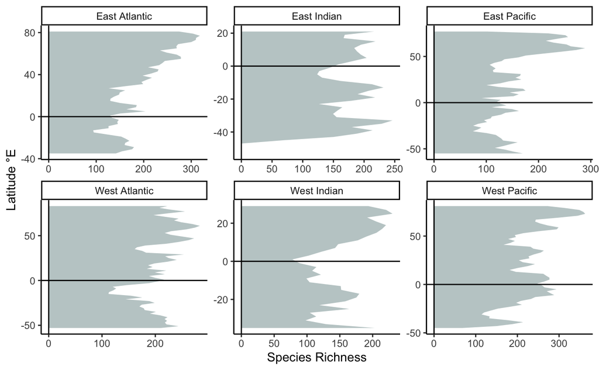

```r
(spp_change_latitude  <- ggplot(data = shelf_areas, aes(x=latitude_mid, y=original_spp_predicted_levin)) +
   geom_area(fill = "azure3") +
 labs(x=paste0("Latitude ","\u00B0","E"), y = "Species Richness") +
  geom_vline(xintercept = 0) +
  geom_hline(yintercept = 0) +
  coord_flip() +
  theme_classic() +
   facet_wrap(~region, scales = "free"))
```

Mark 50% loss or 200% gain of species (this isn’t useful)

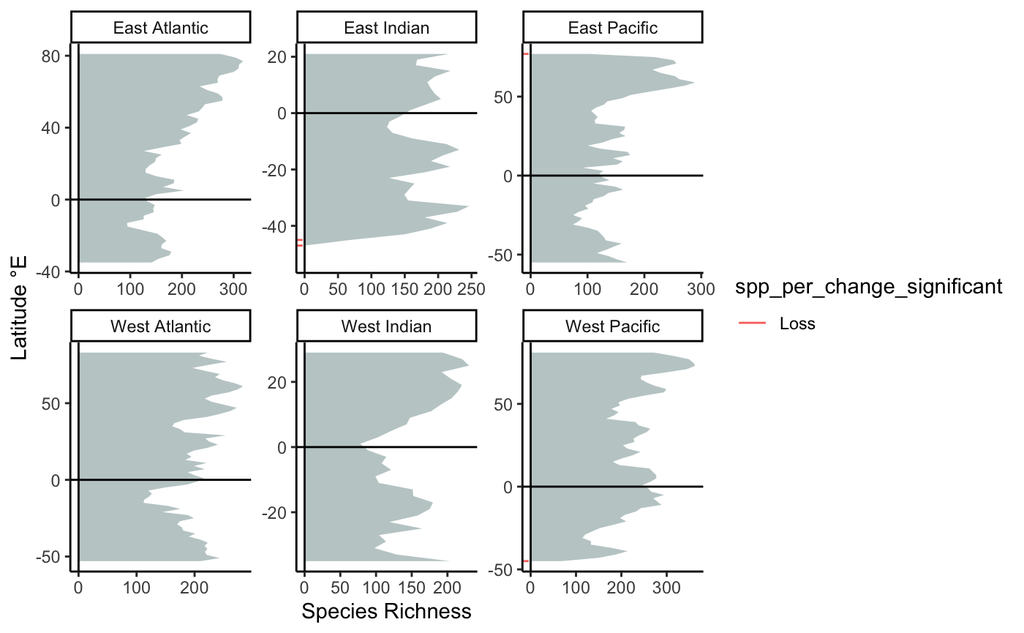

```r
(spp_change_latitude  <- ggplot() +
   geom_area(data = shelf_areas, aes(x=latitude_mid, y = original_spp_predicted_levin), fill = "azure3") +
   geom_rug(data = shelf_areas_highlight, aes(x=latitude_mid, color = spp_per_change_significant)) +
 labs(x=paste0("Latitude ","\u00B0","E"), y = "Species Richness") +
  geom_vline(xintercept = 0) +
  geom_hline(yintercept = 0) +
  coord_flip() +
  theme_classic() +
   facet_wrap(~region, scales = "free"))
```

Figure for spp richness change by latitude

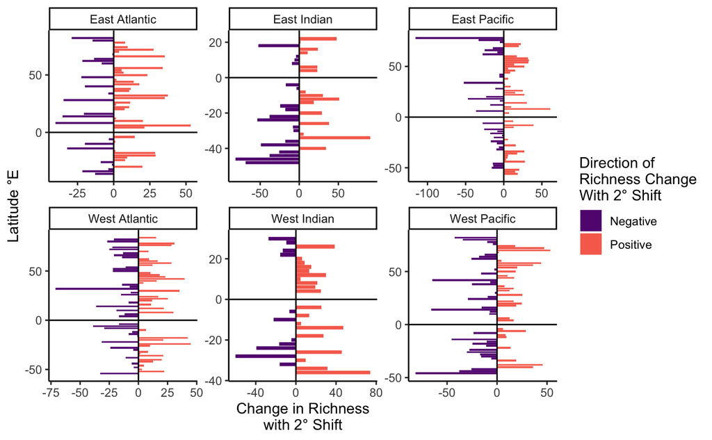

```r
(spp_change_latitude  <- ggplot(data = shelf_areas) +
  geom_col(aes(x=latitude_end, y=change_spp_predicted_levin, fill = change_dir)) +
 labs(x=paste0("Latitude ","\u00B0","E"), y = "Change in Richness\nwith 2\u00B0 Shift") +
     scale_fill_viridis_d(option = "A", begin = 0.3, end = 0.7, name = "Direction of\nRichness Change\nWith 2\u00B0 Shift", labels = c("Negative", "Positive")) +
  geom_vline(xintercept = 0) +
  geom_hline(yintercept = 0) +
  coord_flip() +
  theme_classic() +
   facet_wrap(~region, scales = "free"))
```

Plots instead of tables?

```r
levels(shelf_area_change_hemis_reg_stats$region)
```

```
[1] "East Atlantic" "East Indian"   "East Pacific"  "West Atlantic" "West Indian"   "West Pacific"
```

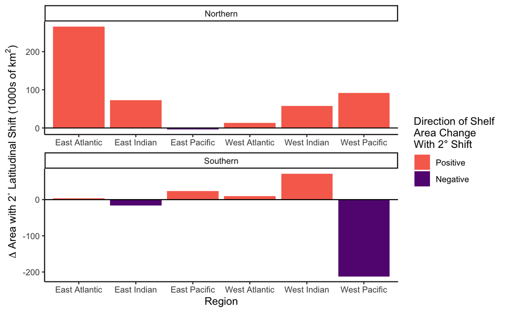

```r
#add return to labels
shelf_area_change_hemis_reg_stats[,region:= factor(region, levels = c("East Atlantic", "East Indian"  , "East Pacific",  "West Atlantic", "West Indian" ,  "West Pacific" ), labels = c("East Atlantic", "East Indian"  , "East Pacific",  "West Atlantic", "West Indian" ,  "West Pacific" ))]

(change_area_reg_hemis <- ggplot(data = shelf_area_change_hemis_reg_stats) +
  geom_col(aes(x = region, y = sum_change_hemis_reg/1000, fill = change_direction)) +
  facet_wrap(~hemisphere, nrow = 2, ncol = 1, scales = "free") +
  labs(x = "Region", y = expression(paste(Delta, " Area with 2˚ Latitudinal Shift (1000s of ", km^{2},")"))) +
  scale_fill_viridis_d(option = "A", begin = 0.7, end = 0.3, name = "Direction of Shelf\nArea Change\nWith 2\u00B0 Shift", labels = c("Positive", "Negative")) +
  geom_hline(yintercept = 0) +
  theme_classic())

ggsave(height = 10, width = 3, file = "shelf_area_change_hemis_reg_stats.jpg")
```

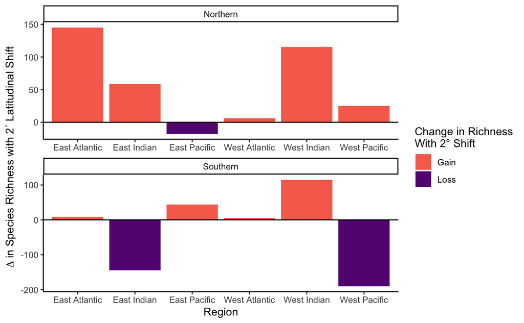

```r
#add return to labels
shelf_spp_change_hemis_reg_stats[,region:= factor(region, levels = c("East Atlantic", "East Indian"  , "East Pacific",  "West Atlantic", "West Indian" ,  "West Pacific" ), labels = c("East Atlantic", "East Indian"  , "East Pacific",  "West Atlantic", "West Indian" ,  "West Pacific" ))]

(change_spp_reg_hemis <- ggplot(data = shelf_spp_change_hemis_reg_stats) +
  geom_col(aes(x = region, y = spp_change_levin_by_reg_hemis, fill = change_direction)) +
  facet_wrap(~hemisphere, nrow = 2, ncol = 1, scales = "free") +
  labs(x = "Region", y =expression(paste(Delta, " in Species Richness with 2˚ Latitudinal Shift"))) +
  scale_fill_viridis_d(option = "A", begin = 0.7, end = 0.3, name = "Change in Richness\nWith 2\u00B0 Shift") +
  geom_hline(yintercept = 0) +
  theme_classic())

ggsave(height = 10, width = 3, file = "shelf_spp_change_hemis_reg_stats.jpg")
```

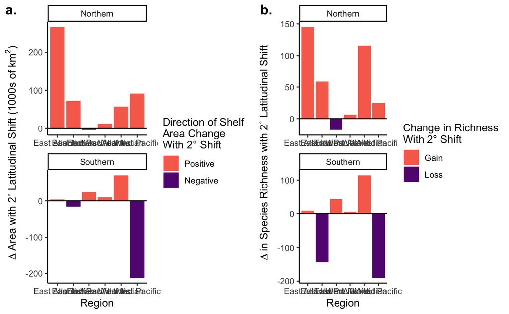

```r
library(cowplot)

plot_grid(change_area_reg_hemis, change_spp_reg_hemis, labels = c("a.","b."))

ggsave(height = 4, width = 10, file = "spp_area_change_Levin2009.jpg")
```

What if instead of this type of plot, we do a bar chart ordered by value?

```r
#merge two columns
shelf_spp_change_hemis_reg_stats[,Coastline := paste(hemisphere,region,sep = "\n")]

#reorder
levels(shelf_spp_change_hemis_reg_stats$change_direction)
```

```
[1] "Gain" "Loss"
```

[figure not shown]

```r
shelf_spp_change_hemis_reg_stats[,change_direction := factor(change_direction, levels = c("Loss","Gain"))]

(ordered_loss_gain_bycoastline <- ggplot(shelf_spp_change_hemis_reg_stats) +
  geom_col(aes(x = reorder(Coastline, spp_change_levin_by_reg_hemis), y = spp_change_levin_by_reg_hemis, fill = change_direction), alpha = 0.8) +
  xlab("Coastline") +
  ylab("Predicted Species Richness\nChange With 2\u00B0 Latitudinal Shift") +
  theme_classic() +
scale_fill_viridis_d(option = "A", begin = 0.3, end = 0.7, name = "Change in Richness\nWith 2\u00B0 Shift") +
  geom_hline(yintercept = 0, size = 0.3) +
  theme(axis.text.x = element_text(angle = 90, size = 10, hjust = 1, vjust = 0.5), legend.title = element_blank()))
```

```r
save(ordered_loss_gain_bycoastline, file = "ordered_loss_gain_bycoastline.RData")
```

Species Area Curves

How much total area to begin with? #FIX THIS

```r
new_total_shelf_area <- sum(shelf_areas[latitude_start > 0])
```

```
Error in FUN(X[[i]], ...) :
  only defined on a data frame with all numeric-alike variables
```

Comparing alternative ways of calculating SAR

Also, Chittaro et al. 2010 (Levin is on this paper as well) spp = 26.1*A^0.183

```r
testareas <- data.table(area= seq(1,10000000,by = 100))
testareas[,Levin_SAR := 16.18*area^0.226][,Chittaro_SAR := 26.1*area^0.183][,Meixler_SAR_30 := exp(6.854 + 0.185 * log(area) -1.084 * log(30))][,Meixler_SAR_1 := exp(6.854 + 0.185 * log(area) -1.084 * log(1))][,Meixler_SAR_5 := exp(6.854 + 0.185 * log(area) -1.084 * log(5))][,Meixler_SAR_60 := exp(6.854 + 0.185 * log(area) -1.084 * log(60))][,Meixler_SAR_80 := exp(6.854 + 0.185 * log(area) -1.084 * log(80))][,Meixler_SAR_70 := exp(6.854 + 0.185 * log(area) -1.084 * log(70))][,Meixler_SAR_10 := exp(6.854 + 0.185 * log(area) -1.084 * log(10))] #includes alternative latitudes

#wide to long
testareas.l <- melt(testareas, measure.vars = c(2:ncol(testareas)))

testareas.l$variable <- factor(testareas.l$variable, levels = c("Levin_SAR","Chittaro_SAR","Meixler_SAR_1" , "Meixler_SAR_5"  ,    "Meixler_SAR_10" ,  "Meixler_SAR_30" , "Meixler_SAR_60","Meixler_SAR_70",
"Meixler_SAR_80" ))

levels(testareas.l$variable)

ggplot(data = testareas.l[variable == "Chittaro_SAR" | variable == "Levin_SAR"], aes(x = area)) +
  geom_point(aes(y = value, color = variable)) +
  labs(x = "Area km^2", y = "# spp") +
  theme_classic()

ggsave(file = "testing_SAR.jpg")
```

[output not shown]

Continuing with Marci’s calculations

spp = exp(6.854 + (0.185 x log(A)) - (1.084 * log(L)))

Let’s make this same figure as area_change_latitude but for species lost or gained instead of area lost or gained

```r
#Meixler
(spp_change_latitude_meixler  <- ggplot(data = shelf_areas) +
  geom_col(aes(x=latitude_end, y=change_spp_predicted_meixler, fill = spp_change_pos_neg_meixler)) +
 labs(x=paste0("Latitude ","\u00B0","E"), y = "Spp Richness") +
     scale_fill_viridis_d(option = "A", begin = 0.3, end = 0.7, name = "Meixler 2019\n\n Richness with 2\u00B0 Shift") +
  geom_vline(xintercept = 0) +
  geom_hline(yintercept = 0) +
  coord_flip() +
  theme_classic() +
   facet_wrap(~region, scales = "free"))


ggsave(spp_change_latitude_meixler, file = "mexlier_spprichness_change_latitude.jpg")

#Meixler ONLY for regions it was calibrated for

#Meixler
(spp_change_latitude_meixler_reduced  <- ggplot(data = shelf_areas[latitude_end_abs > 22 & latitude_end_abs > 46]) +
  geom_col(aes(x=latitude_end, y=change_spp_predicted_meixler, fill = spp_change_pos_neg_meixler)) +
 labs(x=paste0("Latitude ","\u00B0","E"), y = "Spp Richness") +
     scale_fill_viridis_d(option = "A", begin = 0.3, end = 0.7, name = "Meixler 2019\nChange in Species\n Richness with 2\u00B0 Shift") +
  geom_vline(xintercept = 0) +
  geom_hline(yintercept = 0) +
  coord_flip() +
  theme_classic() +
   facet_wrap(~region, scales = "free") +
    lims(y = c(-120, 55)))


ggsave(spp_change_latitude_meixler_reduced, file = "spp_change_latitude_meixler_reduced.jpg")

#Levin

(spp_change_latitude_levin  <- ggplot(data = shelf_areas) +
  geom_col(aes(x=latitude_end, y=change_spp_predicted_levin, fill = spp_change_pos_neg_levin)) +
 labs(x=paste0("Latitude ","\u00B0","E"), y = "Spp Richness") +
     scale_fill_viridis_d(option = "A", begin = 0.3, end = 0.7, name = "Levin 2009\nChange in Species\n Richness with 2\u00B0 Shift") +
  geom_vline(xintercept = 0) +
  geom_hline(yintercept = 0) +
  coord_flip() +
  theme_classic() +
   facet_wrap(~region, scales = "free") +
    lims(y = c(-120, 55)))


ggsave(spp_change_latitude_levin, file = "levin_spprichness_change_latitude.jpg")

#Levin (only for limited Meixler latitudes)

(spp_change_latitude_levin_reduced  <- ggplot(data = shelf_areas[latitude_end_abs > 22 & latitude_end_abs > 46]) +
  geom_col(aes(x=latitude_end, y=change_spp_predicted_levin, fill = spp_change_pos_neg_levin)) +
 labs(x=paste0("Latitude ","\u00B0","E"), y = "Spp Richness") +
     scale_fill_viridis_d(option = "A", begin = 0.3, end = 0.7, name = "Levin 2009\nChange in Species\n Richness with 2\u00B0 Shift") +
  geom_vline(xintercept = 0) +
  geom_hline(yintercept = 0) +
  coord_flip() +
  theme_classic() +
   facet_wrap(~region, scales = "free") +
    lims(y = c(-120, 55)))


ggsave(spp_change_latitude_levin_reduced, file = "spp_change_latitude_levin_reduced.jpg")

#view with area?
plot_grid(area_change_latitude, spp_change_latitude_levin, nrow = 2, ncol = 1)
```

[output not shown]

Try using Phil Levin Indices instead #Spp = 16.18*A^0.226

What if we compare both?

```r
ggplot(data = shelf_areas) +
  geom_point(aes(x = latitude_end_abs, y = original_spp_predicted_meixler), color = "blue") +
    geom_point(aes(x = latitude_end_abs, y = original_spp_predicted_levin), color = "green") +
  theme_classic()
```

[output not shown]

But, what about Chittaro et al. 2010 (Levin is on this paper as well) (Honestly can’t figure why #s are different, let’s go with newer is better?)

spp = 26.1*A^0.183